2019-08-28

## About this presentation

**This talk is for:**

- Data Ops/Engineers/DBAs
- Data Analysts
- BI Analyst & scientists
- For all levels VPs to recent grads

## About Me

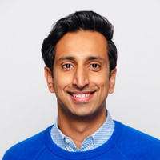

- **Edu:** Penn State (BSEE), RPI (MSEE), UCLA (MBA)
- **Engineering Life:** Sikorsky Helicopters, Boeing
- **Data Life:** Booz Allen, PayPal, Facebook, Xpertly, Retina

# Data Teams

## Data Team The Wrong Way

1. Exec reads about DS in HBR
2. Decides they want it bad in their org
3. Looks for the smartest PhD and hires
4. DS/Analyst joins with excitement only to realize ….
- Business too nascent for data (Product not launched, not much data)
- Should have hired data engineers first (And put data infra in place)
- Hired too few in team
- No clear goal for the data team
- Relegated to running SQL (Data Scientist becomes glorified Excel chart maker)

# Leaves the new hire in a difficult spot

## No credible seat at the table with stakeholders

(Product Management or Sales or Finance)

## Limited career growth

## Moving goal post

## Lack of usable data

## No career guidance

## Feeling of loss of learning

## Likely churns or moves to a new role within months

# Data Done better

- Data is seen as competitive advantage
- Is lead by an analytically minded Exec
- Goals are set clearly in phases

**Phase 1: Transparency and Single Source of Truth** - Hire Data Architect and leaders in Data Ops Engineers. Once data in place, hire BI team and buy BI tools to remove SQL dependency.

**Phase 2 : Experimentation & Forecasting** - Hire DS to get simple things right. Work with Product to run experiments and build infra for experimentation. Reporting advances from historical to predictive.

**Phase 3: Customization** - Enable customized experiences for users, with one off tests and results of Data driven experiments show incremental results.

**Goal 4: Automation** - Automation of workflow for product, marketing, sales and customer service.

# Outcomes of Data Science Done Better

## The Good

- High impact on business
- Likely to be at cutting edge of Data Analytics
- Data people are cherished and listened to
- You get a chance own the room
- Career growth within DS highly probable

## The Bad

- Data fatigue- only get to play with one data set
- Not directly contributing to revenue of the company
- May fail to tie day to day work with business impact

# Organizational Strategies

## Types of Companies

The strategy you use may vary based on the size and stage of the company, but almost never based on the vertical

## Model 2: Large Org Distributed Teams

## Model 3: Large Org Hybrid

## Model 4: Medium/Small Org

Small team connected to C-Suite (CFO/CMO)

# Currently in a Data Role?

## Data Roles Map

- Levels : Analyst/Scientist > Sr. Analyst/Scientist > Manager/Lead > Director > VP > CDO
- Roles: Infra & Ops, Business Intelligence, Research Scientist, Developer, DBA, Measurement
- Functions: Product Strategy & Ops, Finance, Marketing/Growth, HR, Supply Chain
- Pick a path and ask your leadership about expectations for reaching next level

## Two existential questions you should think about

- Is my work directly tied to the revenue stream of the company?
- Am I growing my skills after working here for two years? (is there a diversity of data sets and problems)

## Careers Out of Data

- Product Management
- Operations Management
- Client Partnership
- Business Development

# What should I know if I am job seeker/switcher?

## What are businesses looking for in candidates?

- Focus on Business Impact
- Bring Diverse Skill Sets (DS + DE)
- Have Some Deep Expertise
- Realistic Expectations

## What are candidates looking for?

- Flexibility
- Career Progression
- Competitive Salary
- Good Management
- Good company culture

## Some interesting stats [^1]

- Still a large gender bias - Only 23% of professionals are female
- Job Seeker’s market - 72% of professionals would leave current role for next good opportunity
- Highest flexibilty in work - 64% have flexible work hours or can work from home
- 2 Years still remains the typical length of time in role

# Resources

## Book [Deep Work: Rules for Focused Success in a Distracted World](https://www.amazon.com/Deep-Work-Focused-Success-Distracted/dp/1455586692/)

## Link [The Five Dysfunctions of a Data Science Team](https://www.slideshare.net/continuumio/the-five-dysfunctions-of-a-data-science-team)

## Link [Machine Learning Engineer vs. Data Scientist](https://www.springboard.com/blog/machine-learning-engineer-vs-data-scientist/)

## Link [Data Salary Guide](https://www.harnham.com/harnham-us-data-analytics-salary-guide-2019)

## Other Links

- https://retina.ai/blog/dataops-principles/
- https://retina.ai/blog/7-ways-machine-learning-projects-fail/

# Thank you (emad@retina.ai)

[^1]: Data & Analytics Salary Guide 2019 (Harnam).↩